# **Loading the dataset**

The dataset contains real-life driving data of two Volkswagen e-Golf cars, with year of manufacture as 2014 and 2016 respectively. The data is available at the [Spritmonitor](https://www.spritmonitor.de/en/) website.

Volkswagen e-Golf, year 2014, 85 kW (116 PS): https://www.spritmonitor.de/en/detail/679341.html?page=8

Volkswagen e-Golf, year 2016, 85kW (116 PS): https://www.spritmonitor.de/en/detail/786327.html

The data was scrapped using a python crawler (vehicle_crawler.py) available at: https://github.com/armiro/crawlers/tree/master/SpritMonitor-Crawler

The file includes data about **3615 trips** with a total travel distance of around **152167 kilometers**.

It is important to restrict the dataset to a limited number of cars. If data of the same type of car, owned by different people around the world, is included in the same dataset then it leads to instability in the model training. Hence, it is important to make sure that the dataset should not contain data of cars driven in too varied conditions.

**Note:** Some of the features were trimmed from the original CSV file before being loaded in the notebook.

```python
import pandas as pd

data =  pd.read_csv('/content/drive/MyDrive/Colab Notebooks/Projects/EV Range Prediction/Dataset/Volks.csv')
data.head()
```

|  | Manufacturer | Power(kW) | Quantity(kWh) | Tire_Type | City | Highway | Country_Roads | Driving_Style | A/C | Park_heating | Avg_Speed(km/h) | Trip_Distance(km) |
| --- | --- | --- | --- | --- | --- | --- | --- | --- | --- | --- | --- | --- |
| 0 | Volkswagen | 85 | 2.41 | Summer tires | 1 | 0 | 1 | Normal | 0 | 0 | 44.0 | 21.0 |
| 1 | Volkswagen | 85 | 13.17 | Summer tires | 1 | 1 | 1 | Normal | 0 | 0 | 57.0 | 108.0 |
| 2 | Volkswagen | 85 | 8.89 | Summer tires | 1 | 1 | 1 | Normal | 0 | 0 | 52.0 | 76.0 |
| 3 | Volkswagen | 85 | 12.46 | Summer tires | 1 | 1 | 1 | Normal | 0 | 0 | 63.0 | 103.0 |
| 4 | Volkswagen | 85 | 8.97 | Summer tires | 1 | 0 | 1 | Normal | 0 | 0 | 38.0 | 78.0 |

# **Checking the type of data in each column**

To check for categorical and non-categorical features in the dataset.

```python
data.info()
```

```
<class 'pandas.core.frame.DataFrame'>
RangeIndex: 3615 entries, 0 to 3614
Data columns (total 12 columns):
 #   Column             Non-Null Count  Dtype
---  ------             --------------  -----
 0   Manufacturer       3615 non-null   object
 1   Power(kW)          3615 non-null   int64
 2   Quantity(kWh)      3615 non-null   float64
 3   Tire_Type          3615 non-null   object
 4   City               3615 non-null   int64
 5   Highway            3615 non-null   int64
 6   Country_Roads      3615 non-null   int64
 7   Driving_Style      3615 non-null   object
 8   A/C                3615 non-null   int64
 9   Park_heating       3615 non-null   int64
 10  Avg_Speed(km/h)    3585 non-null   float64
 11  Trip_Distance(km)  3615 non-null   float64
dtypes: float64(3), int64(6), object(3)
memory usage: 339.0+ KB
```

# **Removing unnecessary features**

Since, the dataset contains data related to only one car i.e., **Volkswagen Golf**, the Manufacturer and Power(kW) of battery are constant. Hence, they can be safely dropped from the dataset, without leading to any loss of valuable information.

```python
data.drop(['Manufacturer','Power(kW)'], axis=1, inplace=True)
```

# **Removing all rows with missing values for Trip_Distance(km)**

All the rows/ records with missing values of Trip_Distance(km) should be removed. These values cannot be imputed, because this is the target variable.

```python
data = data[data['Trip_Distance(km)'].isnull() == False]
data.info()
```

```
<class 'pandas.core.frame.DataFrame'>
Int64Index: 3615 entries, 0 to 3614
Data columns (total 10 columns):
 #   Column             Non-Null Count  Dtype
---  ------             --------------  -----
 0   Quantity(kWh)      3615 non-null   float64
 1   Tire_Type          3615 non-null   object
 2   City               3615 non-null   int64
 3   Highway            3615 non-null   int64
 4   Country_Roads      3615 non-null   int64
 5   Driving_Style      3615 non-null   object
 6   A/C                3615 non-null   int64
 7   Park_heating       3615 non-null   int64
 8   Avg_Speed(km/h)    3585 non-null   float64
 9   Trip_Distance(km)  3615 non-null   float64
dtypes: float64(3), int64(5), object(2)
memory usage: 310.7+ KB
```

# **One-Hot Encoding the categorical variables (Types of tires and driving styles)**

The categorical variables cannot be used in the dataset for training the model. They have to be converted into a an integer representation of boolean form, i.e. 1/0

```python
data.select_dtypes('object')
```

|  | Tire_Type | Driving_Style |
| --- | --- | --- |
| 0 | Summer tires | Normal |
| 1 | Summer tires | Normal |
| 2 | Summer tires | Normal |
| 3 | Summer tires | Normal |
| 4 | Summer tires | Normal |
| ... | ... | ... |
| 3610 | Winter tires | Normal |
| 3611 | Winter tires | Normal |
| 3612 | Winter tires | Normal |
| 3613 | Winter tires | Fast |
| 3614 | Winter tires | Normal |

3615 rows × 2 columns

```python
print('Unique tire types:', data['Tire_Type'].unique())
print('Unique driving styles:', data['Driving_Style'].unique())
```

```
Unique tire types: ['Summer tires' 'Winter tires']
Unique driving styles: ['Normal' 'Moderate' 'Fast']
```

### **Encoding types of tires**

```python
for each in data['Tire_Type'].unique():
    data['Tire_Type '+each] = list(map(int, data['Tire_Type']==each))

data.drop(['Tire_Type'], axis=1, inplace=True)
data.head()
```

|  | Quantity(kWh) | City | Highway | Country_Roads | Driving_Style | A/C | Park_heating | Avg_Speed(km/h) | Trip_Distance(km) | Tire_Type Summer tires | Tire_Type Winter tires |
| --- | --- | --- | --- | --- | --- | --- | --- | --- | --- | --- | --- |
| 0 | 2.41 | 1 | 0 | 1 | Normal | 0 | 0 | 44.0 | 21.0 | 1 | 0 |
| 1 | 13.17 | 1 | 1 | 1 | Normal | 0 | 0 | 57.0 | 108.0 | 1 | 0 |
| 2 | 8.89 | 1 | 1 | 1 | Normal | 0 | 0 | 52.0 | 76.0 | 1 | 0 |
| 3 | 12.46 | 1 | 1 | 1 | Normal | 0 | 0 | 63.0 | 103.0 | 1 | 0 |
| 4 | 8.97 | 1 | 0 | 1 | Normal | 0 | 0 | 38.0 | 78.0 | 1 | 0 |

### **Encoding types of driving styles**

```python
for each in data['Driving_Style'].unique():
    data['Driving_Style '+each] = list(map(int, data['Driving_Style']==each))

data.drop(['Driving_Style'], axis=1, inplace=True)
data.head()
```

|  | Quantity(kWh) | City | Highway | Country_Roads | A/C | Park_heating | Avg_Speed(km/h) | Trip_Distance(km) | Tire_Type Summer tires | Tire_Type Winter tires | Driving_Style Normal | Driving_Style Moderate | Driving_Style Fast |
| --- | --- | --- | --- | --- | --- | --- | --- | --- | --- | --- | --- | --- | --- |
| 0 | 2.41 | 1 | 0 | 1 | 0 | 0 | 44.0 | 21.0 | 1 | 0 | 1 | 0 | 0 |
| 1 | 13.17 | 1 | 1 | 1 | 0 | 0 | 57.0 | 108.0 | 1 | 0 | 1 | 0 | 0 |
| 2 | 8.89 | 1 | 1 | 1 | 0 | 0 | 52.0 | 76.0 | 1 | 0 | 1 | 0 | 0 |
| 3 | 12.46 | 1 | 1 | 1 | 0 | 0 | 63.0 | 103.0 | 1 | 0 | 1 | 0 | 0 |
| 4 | 8.97 | 1 | 0 | 1 | 0 | 0 | 38.0 | 78.0 | 1 | 0 | 1 | 0 | 0 |

Checking the data types of the encoded features

```python
data.info()
```

```
<class 'pandas.core.frame.DataFrame'>
Int64Index: 3615 entries, 0 to 3614
Data columns (total 13 columns):
 #   Column                  Non-Null Count  Dtype
---  ------                  --------------  -----
 0   Quantity(kWh)           3615 non-null   float64
 1   City                    3615 non-null   int64
 2   Highway                 3615 non-null   int64
 3   Country_Roads           3615 non-null   int64
 4   A/C                     3615 non-null   int64
 5   Park_heating            3615 non-null   int64
 6   Avg_Speed(km/h)         3585 non-null   float64
 7   Trip_Distance(km)       3615 non-null   float64
 8   Tire_Type Summer tires  3615 non-null   int64
 9   Tire_Type Winter tires  3615 non-null   int64
 10  Driving_Style Normal    3615 non-null   int64
 11  Driving_Style Moderate  3615 non-null   int64
 12  Driving_Style Fast      3615 non-null   int64
dtypes: float64(3), int64(10)
memory usage: 395.4 KB
```

# **Shuffling and splitting the data it into training and test sets**

### **Dividing the dataset into features (X) and label (Y)**

```python
data = data.sample(frac=1)

Y = data['Trip_Distance(km)']
X = data.drop(['Trip_Distance(km)'], axis=1)

X.reset_index(level=None, drop=True, inplace=True, col_level=0, col_fill='')
Y.reset_index(level=None, drop=True, inplace=True)
```

### **Dividing the features into training (80%) and testing (20%) datasets for model training and evaluation respectively**

```python
from sklearn.model_selection import train_test_split

X_train, X_test, Y_train, Y_test = train_test_split(X, Y, train_size=0.8, random_state=1)

X_train.reset_index(level=None, drop=True, inplace=True, col_level=0, col_fill='')
X_test.reset_index(level=None, drop=True, inplace=True, col_level=0, col_fill='')
Y_train.reset_index(level=None, drop=True, inplace=True)
Y_test.reset_index(level=None, drop=True, inplace=True)

print(X_train.shape, Y_train.shape, X_test.shape, Y_test.shape)
```

```
(2892, 12) (2892,) (723, 12) (723,)
```

# **Looking for columns with missing values in training set**

Missing values for numerical/ non-categorical features is to be imputed using the rest of the data in the same feature.

```python
X_train.isnull().any()
```

```
Quantity(kWh)             False
City                      False
Highway                   False
Country_Roads             False
A/C                       False
Park_heating              False
Avg_Speed(km/h)            True
Tire_Type Summer tires    False
Tire_Type Winter tires    False
Driving_Style Normal      False
Driving_Style Moderate    False
Driving_Style Fast        False
dtype: bool
```

# **Imputing the missing values**

Here, we have used a simple imputer using the 'mean strategy', i.e. the missing values will be replaced by the mean of non-missing values in that feature.

```python
from sklearn.impute import SimpleImputer
imputer = SimpleImputer(strategy='mean')

cols_with_missing_data = [cols for cols in X_train.columns
                         if X_train[cols].isnull().any()]

X_train_imputed_data_columns = pd.DataFrame(imputer.fit_transform(X_train[cols_with_missing_data]))
X_test_imputed_data_columns = pd.DataFrame(imputer.transform(X_test[cols_with_missing_data]))

X_train_imputed_data_columns.columns = cols_with_missing_data
X_test_imputed_data_columns.columns = cols_with_missing_data

X_train = pd.concat([X_train.drop(cols_with_missing_data, axis=1, inplace=False), X_train_imputed_data_columns], axis=1)
X_test = pd.concat([X_test.drop(cols_with_missing_data, axis=1, inplace=False), X_test_imputed_data_columns], axis=1)
```

Checking the number of non-null values in each column of the dataset

```python
X_train.info()
```

```
<class 'pandas.core.frame.DataFrame'>
RangeIndex: 2892 entries, 0 to 2891
Data columns (total 12 columns):
 #   Column                  Non-Null Count  Dtype
---  ------                  --------------  -----
 0   Quantity(kWh)           2892 non-null   float64
 1   City                    2892 non-null   int64
 2   Highway                 2892 non-null   int64
 3   Country_Roads           2892 non-null   int64
 4   A/C                     2892 non-null   int64
 5   Park_heating            2892 non-null   int64
 6   Tire_Type Summer tires  2892 non-null   int64
 7   Tire_Type Winter tires  2892 non-null   int64
 8   Driving_Style Normal    2892 non-null   int64
 9   Driving_Style Moderate  2892 non-null   int64
 10  Driving_Style Fast      2892 non-null   int64
 11  Avg_Speed(km/h)         2892 non-null   float64
dtypes: float64(2), int64(10)
memory usage: 271.2 KB
```

```python
X_test.info()
```

```
<class 'pandas.core.frame.DataFrame'>
RangeIndex: 723 entries, 0 to 722
Data columns (total 12 columns):
 #   Column                  Non-Null Count  Dtype
---  ------                  --------------  -----
 0   Quantity(kWh)           723 non-null    float64
 1   City                    723 non-null    int64
 2   Highway                 723 non-null    int64
 3   Country_Roads           723 non-null    int64
 4   A/C                     723 non-null    int64
 5   Park_heating            723 non-null    int64
 6   Tire_Type Summer tires  723 non-null    int64
 7   Tire_Type Winter tires  723 non-null    int64
 8   Driving_Style Normal    723 non-null    int64
 9   Driving_Style Moderate  723 non-null    int64
 10  Driving_Style Fast      723 non-null    int64
 11  Avg_Speed(km/h)         723 non-null    float64
dtypes: float64(2), int64(10)
memory usage: 67.9 KB
```

# **Outlier Analysis**

```python
import numpy as np
from scipy.stats import norm
import matplotlib.pyplot as plt
%matplotlib inline

# Outlier analysis is used for identifying outlying continuous data.
# In our dataset Quantity(kWh) & Avg_Speed(km/h) are the only continuos data apart from the target variable.
```

### **For Average Speed (km/hr)**

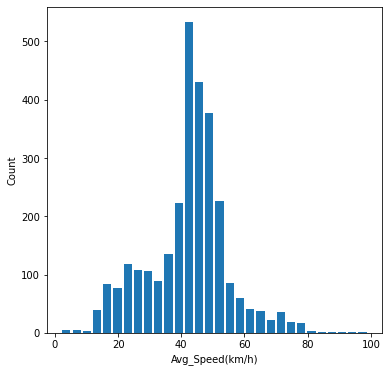

```python
plt.figure(figsize=(6,6))
plt.hist(X_train['Avg_Speed(km/h)'], bins=30, rwidth=0.8)
plt.xlabel('Avg_Speed(km/h)')
plt.ylabel('Count')
plt.show()
```

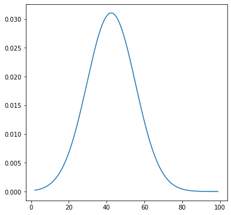

```python
plt.figure(figsize=(6,6))
rng = np.arange(X_train['Avg_Speed(km/h)'].min(), X_train['Avg_Speed(km/h)'].max(), 0.1)
plt.plot(rng, norm.pdf(rng, X_train['Avg_Speed(km/h)'].mean(), X_train['Avg_Speed(km/h)'].std()))
plt.show()
```

```python
# It could be cleary seen from the bell shaped curve that the data for average speed is normalized
# Thus removing outliers depending upon the z-score

X_train['Speed_z_score'] = (X_train['Avg_Speed(km/h)'] - X_train['Avg_Speed(km/h)'].mean())/X_train['Avg_Speed(km/h)'].std()
X_test['Speed_z_score'] = (X_test['Avg_Speed(km/h)'] - X_test['Avg_Speed(km/h)'].mean())/X_test['Avg_Speed(km/h)'].std()

# Reomving inputes with z-score of more than 3 or less than -3 for average speed
to_be_included_train = (X_train['Speed_z_score']<3) | (X_train['Speed_z_score']>-3)
to_be_included_test = (X_test['Speed_z_score']<3) | (X_test['Speed_z_score']>-3)

X_train = X_train[to_be_included_train]
Y_train = Y_train[to_be_included_train]

X_test = X_test[to_be_included_test]
Y_test = Y_test[to_be_included_test]

X_train.drop(['Speed_z_score'], axis=1, inplace=True)
X_test.drop(['Speed_z_score'], axis=1, inplace=True)

print(X_train.shape, Y_train.shape, X_test.shape, Y_test.shape)
```

```
(2892, 12) (2892,) (723, 12) (723,)
```

### **For Quantity(kWh)**

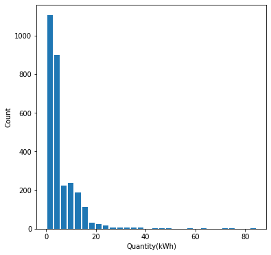

```python
plt.figure(figsize=(6,6))
plt.hist(X_train['Quantity(kWh)'], bins=30, rwidth=0.8)
plt.xlabel('Quantity(kWh)')
plt.ylabel('Count')
plt.show()
```

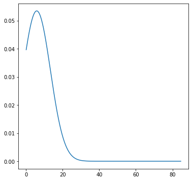

```python
plt.figure(figsize=(6,6))
rng = np.arange(X_train['Quantity(kWh)'].min(), X_train['Quantity(kWh)'].max(), 0.1)
plt.plot(rng, norm.pdf(rng, X_train['Quantity(kWh)'].mean(), X_train['Quantity(kWh)'].std()))
plt.show()
```

```python
# From the curve it is concluded that the Quantity(kWh) is not distributed normally
# Hence, removing all the rows with Quantity(kWh) greater than 65kWh

to_be_included_train = X_train['Quantity(kWh)']<=65
to_be_included_test = X_test['Quantity(kWh)']<=65

X_train = X_train[to_be_included_train]
Y_train = Y_train[to_be_included_train]

X_test = X_test[to_be_included_test]
Y_test = Y_test[to_be_included_test]

print(X_train.shape, Y_train.shape, X_test.shape, Y_test.shape)

X_train.reset_index(level=None, drop=True, inplace=True, col_level=0, col_fill='')
X_test.reset_index(level=None, drop=True, inplace=True, col_level=0, col_fill='')
Y_train.reset_index(level=None, drop=True, inplace=True)
Y_test.reset_index(level=None, drop=True, inplace=True)
```

```
(2884, 12) (2884,) (723, 12) (723,)
```

# **Correlation between different features**

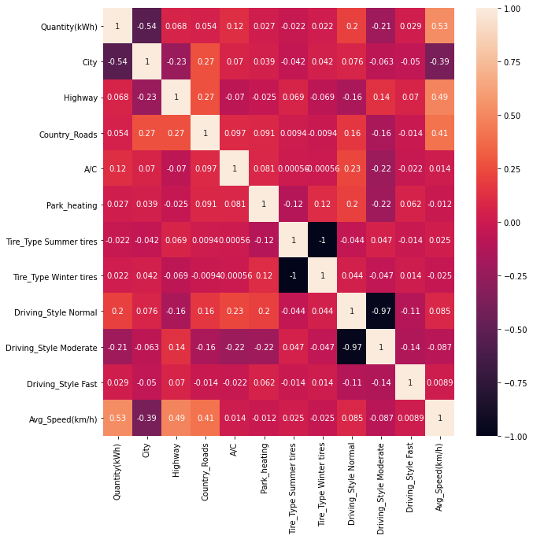

```python
import seaborn as sns
import matplotlib.pyplot as plt

plt.figure(figsize=(10,10))
sns.heatmap(X_train.corr(method='pearson'), annot=True)
plt.show()
```

As it could be seen from the heatmap that the Driving_Style Normal & Driving_Style Moderate are possessing strong negative correlation, one of them needs to be dropped. Same goes for Summer & winter tire types.

```python
X_train = X_train.drop(['Driving_Style Normal', 'Tire_Type Summer tires'], axis=1)
X_test = X_test.drop(['Driving_Style Normal', 'Tire_Type Summer tires'], axis=1)
```

# **Tensorflow Model**

Preparing a neural network model in tensorflow for this regression problem.

### **Importing the necessary libraries**

```python
import tensorflow as tf
import tensorflowjs
import keras
from tensorflow.keras.models import Sequential
from tensorflow.keras.layers import Dense
from keras import regularizers
```

### **Normalizing the continuos features before feeding it to the neural net**

```python
cols_to_be_normalized = ['Quantity(kWh)', 'Avg_Speed(km/h)']

for each in cols_to_be_normalized:
    mean = X_train[each].mean()
    std = X_train[each].std()

    X_train[each] = (X_train[each] - mean)/std
    X_test[each] = (X_test[each] - mean)/std
```

```python
X_train
```

|  | Quantity(kWh) | City | Highway | Country_Roads | A/C | Park_heating | Tire_Type Winter tires | Driving_Style Moderate | Driving_Style Fast | Avg_Speed(km/h) |
| --- | --- | --- | --- | --- | --- | --- | --- | --- | --- | --- |
| 0 | 0.262074 | 1 | 0 | 1 | 0 | 0 | 1 | 0 | 0 | 0.132081 |
| 1 | -0.706020 | 1 | 0 | 0 | 0 | 1 | 1 | 1 | 0 | -0.965159 |
| 2 | -0.608280 | 1 | 1 | 1 | 0 | 0 | 1 | 1 | 0 | -1.200282 |
| 3 | -0.273170 | 1 | 1 | 1 | 0 | 0 | 1 | 1 | 0 | 0.288829 |
| 4 | -0.384874 | 1 | 0 | 1 | 1 | 0 | 1 | 0 | 0 | -0.338165 |
| ... | ... | ... | ... | ... | ... | ... | ... | ... | ... | ... |
| 2879 | -0.432968 | 1 | 0 | 1 | 0 | 0 | 0 | 1 | 0 | -1.121908 |
| 2880 | 1.034687 | 1 | 1 | 1 | 0 | 0 | 0 | 1 | 0 | 0.759075 |
| 2881 | -0.571046 | 1 | 0 | 0 | 0 | 0 | 1 | 1 | 0 | -0.416539 |
| 2882 | -0.577251 | 1 | 0 | 0 | 0 | 0 | 0 | 0 | 0 | -1.357031 |
| 2883 | -0.308853 | 1 | 0 | 1 | 0 | 0 | 0 | 0 | 0 | -0.024668 |

2884 rows × 10 columns

```python
X_test
```

|  | Quantity(kWh) | City | Highway | Country_Roads | A/C | Park_heating | Tire_Type Winter tires | Driving_Style Moderate | Driving_Style Fast | Avg_Speed(km/h) |
| --- | --- | --- | --- | --- | --- | --- | --- | --- | --- | --- |
| 0 | -0.319713 | 1 | 1 | 1 | 0 | 0 | 0 | 0 | 0 | 0.445578 |
| 1 | -0.468651 | 1 | 0 | 1 | 0 | 0 | 0 | 1 | 0 | -1.670528 |
| 2 | -0.840995 | 1 | 0 | 0 | 0 | 0 | 1 | 1 | 0 | -1.670528 |
| 3 | -0.329022 | 1 | 1 | 1 | 0 | 0 | 0 | 1 | 0 | 0.367204 |
| 4 | -0.856509 | 1 | 0 | 0 | 0 | 0 | 0 | 1 | 0 | -1.748902 |
| ... | ... | ... | ... | ... | ... | ... | ... | ... | ... | ... |
| 718 | 0.893507 | 1 | 1 | 1 | 0 | 0 | 1 | 0 | 0 | 1.307695 |
| 719 | -0.712226 | 1 | 0 | 0 | 0 | 0 | 1 | 1 | 0 | -1.278656 |
| 720 | -0.360051 | 1 | 1 | 1 | 0 | 0 | 0 | 1 | 0 | 0.288829 |
| 721 | 1.372900 | 1 | 0 | 1 | 1 | 0 | 0 | 0 | 0 | -0.024668 |
| 722 | 0.994350 | 1 | 0 | 1 | 0 | 0 | 1 | 0 | 0 | -0.259791 |

723 rows × 10 columns

### **Bulding a sequential model**

```python
model = Sequential()
model.add(Dense(units=32, activation='relu', input_dim=len(X_train.columns)))
model.add(Dense(units=32, activation='relu'))
model.add(Dense(units=1, activation='linear'))

batch_size = 16     # batch size for model fitting

epochs = 1000       # number of epochs for model fitting

STEPS_PER_EPOCH = X_train.shape[0]/batch_size

es = keras.callbacks.EarlyStopping(monitor='val_loss', patience=50, verbose=0) # Early stopping to prevent overfitting

lr_schedule = tf.keras.optimizers.schedules.InverseTimeDecay(                  # Using a dynamic learning rate that decays a certain rate per 100 epochs
  0.001,
  decay_steps=STEPS_PER_EPOCH*100,
  decay_rate=0.98,
  staircase=False)

opt = keras.optimizers.RMSprop(lr_schedule)   # Using RMSprop optimizer with the learning rate schedule as mentioned above

model.compile(loss='mae', optimizer=opt, metrics=['mae'])
model.summary()
```

```
Model: "sequential"
_________________________________________________________________
Layer (type)                 Output Shape              Param #
=================================================================
dense (Dense)                (None, 32)                352
_________________________________________________________________
dense_1 (Dense)              (None, 32)                1056
_________________________________________________________________
dense_2 (Dense)              (None, 1)                 33
=================================================================
Total params: 1,441
Trainable params: 1,441
Non-trainable params: 0
_________________________________________________________________
```

### **Fitting the model to the training data**

```python
model.fit(X_train, Y_train, epochs=epochs, batch_size=batch_size, callbacks=[es], validation_split=0.2, validation_data=None, verbose=1)
```

```
<tensorflow.python.keras.callbacks.History at 0x7fc4b20b1e10>
```

### **Making predictions for the test dataset and evaluating the model on the basis of mean absolute error**

```python
from sklearn.metrics import mean_absolute_error
predictions = (model.predict(X_test))
print(mean_absolute_error(Y_test, predictions))
```

```
3.1801840226844797
```

```python
compare = pd.concat([pd.DataFrame(predictions), pd.DataFrame(Y_test)], axis=1)
compare.columns = ['Predictions', 'Actual Output']
compare
```

|  | Predictions | Actual Output |
| --- | --- | --- |
| 0 | 19.853456 | 20.0 |
| 1 | 24.822134 | 21.0 |
| 2 | 1.678609 | 2.0 |
| 3 | 19.744425 | 20.0 |
| 4 | 1.367931 | 1.0 |
| ... | ... | ... |
| 718 | 74.930794 | 78.0 |
| 719 | 8.039471 | 6.0 |
| 720 | 19.390198 | 20.0 |
| 721 | 126.380241 | 134.0 |
| 722 | 71.318306 | 65.0 |

723 rows × 2 columns

### **Calculating the standard deviation of the test labels**

```python
Y_test.std()
```

```
43.84078892739657
```

As per the research paper (https://sci-hub.se/10.1109/ICSPIS48872.2019.9066042), **a model having a MAE of less than 10% of standard deviation of the label (for regression), i.e. 4.384 km in our case, is considered as an excellent model.** the MAE of our model for test data is 3.18 (approximately). Hence, it can considered as a reliable model.

# **Saving and exporting JSON version of the model**

```python
import tensorflowjs

model.save('/content/drive/MyDrive/Colab Notebooks/Projects/EV Range Prediction/Model (Final)/range_prediction_model.h5')
tensorflowjs.converters.save_keras_model(model, '/content/drive/MyDrive/Colab Notebooks/Projects/EV Range Prediction/Model (Final)/JSON')
```